# Risk Factor Analysis

## Outcome Variable

**Outcome Variable:** wast_rec90d

## Predictor Variables

**Intervention Variable:** parity

**Adjustment Set:**

- arm
- W_mage
- meducyrs
- feducyrs
- hhwealth_quart
- W_mhtcm
- W_mwtkg
- W_mbmi
- vagbrth
- W_nrooms
- impsan
- delta_W_mage
- delta_meducyrs
- delta_feducyrs
- delta_hhwealth_quart
- delta_W_mhtcm
- delta_W_mwtkg
- delta_W_mbmi
- delta_vagbrth
- delta_W_nrooms
- delta_impsan

## Stratifying Variables

The analysis was stratified on these variable(s):

- agecat
- studyid
- country

## Data Summary

| agecat | studyid | country | parity | wast_rec90d | n_cell | n |
| --- | --- | --- | --- | --- | --- | --- |
| 0-24 months | ki1000304b-SAS-CompFeed | INDIA | 1 | 0 | 136 | 814 |
| 0-24 months | ki1000304b-SAS-CompFeed | INDIA | 1 | 1 | 91 | 814 |
| 0-24 months | ki1000304b-SAS-CompFeed | INDIA | 2 | 0 | 110 | 814 |
| 0-24 months | ki1000304b-SAS-CompFeed | INDIA | 2 | 1 | 62 | 814 |
| 0-24 months | ki1000304b-SAS-CompFeed | INDIA | 3+ | 0 | 258 | 814 |
| 0-24 months | ki1000304b-SAS-CompFeed | INDIA | 3+ | 1 | 157 | 814 |
| 0-24 months | ki1000304b-SAS-FoodSuppl | INDIA | 1 | 0 | 11 | 234 |
| 0-24 months | ki1000304b-SAS-FoodSuppl | INDIA | 1 | 1 | 0 | 234 |
| 0-24 months | ki1000304b-SAS-FoodSuppl | INDIA | 2 | 0 | 30 | 234 |
| 0-24 months | ki1000304b-SAS-FoodSuppl | INDIA | 2 | 1 | 2 | 234 |
| 0-24 months | ki1000304b-SAS-FoodSuppl | INDIA | 3+ | 0 | 180 | 234 |
| 0-24 months | ki1000304b-SAS-FoodSuppl | INDIA | 3+ | 1 | 11 | 234 |
| 0-24 months | ki1017093b-PROVIDE | BANGLADESH | 1 | 0 | 52 | 308 |
| 0-24 months | ki1017093b-PROVIDE | BANGLADESH | 1 | 1 | 76 | 308 |
| 0-24 months | ki1017093b-PROVIDE | BANGLADESH | 2 | 0 | 40 | 308 |
| 0-24 months | ki1017093b-PROVIDE | BANGLADESH | 2 | 1 | 63 | 308 |
| 0-24 months | ki1017093b-PROVIDE | BANGLADESH | 3+ | 0 | 37 | 308 |
| 0-24 months | ki1017093b-PROVIDE | BANGLADESH | 3+ | 1 | 40 | 308 |
| 0-24 months | ki1066203-TanzaniaChild2 | TANZANIA, UNITED REPUBLIC OF | 1 | 0 | 90 | 702 |
| 0-24 months | ki1066203-TanzaniaChild2 | TANZANIA, UNITED REPUBLIC OF | 1 | 1 | 158 | 702 |
| 0-24 months | ki1066203-TanzaniaChild2 | TANZANIA, UNITED REPUBLIC OF | 2 | 0 | 83 | 702 |
| 0-24 months | ki1066203-TanzaniaChild2 | TANZANIA, UNITED REPUBLIC OF | 2 | 1 | 155 | 702 |
| 0-24 months | ki1066203-TanzaniaChild2 | TANZANIA, UNITED REPUBLIC OF | 3+ | 0 | 90 | 702 |
| 0-24 months | ki1066203-TanzaniaChild2 | TANZANIA, UNITED REPUBLIC OF | 3+ | 1 | 126 | 702 |
| 0-24 months | ki1101329-Keneba | GAMBIA | 1 | 0 | 46 | 1438 |
| 0-24 months | ki1101329-Keneba | GAMBIA | 1 | 1 | 120 | 1438 |
| 0-24 months | ki1101329-Keneba | GAMBIA | 2 | 0 | 44 | 1438 |
| 0-24 months | ki1101329-Keneba | GAMBIA | 2 | 1 | 95 | 1438 |
| 0-24 months | ki1101329-Keneba | GAMBIA | 3+ | 0 | 436 | 1438 |
| 0-24 months | ki1101329-Keneba | GAMBIA | 3+ | 1 | 697 | 1438 |

[output cut: 168 more lines]

The following strata were considered:

- agecat: 0-24 months, studyid: ki1000304b-SAS-CompFeed, country: INDIA
- agecat: 0-24 months, studyid: ki1000304b-SAS-FoodSuppl, country: INDIA
- agecat: 0-24 months, studyid: ki1017093b-PROVIDE, country: BANGLADESH
- agecat: 0-24 months, studyid: ki1066203-TanzaniaChild2, country: TANZANIA, UNITED REPUBLIC OF
- agecat: 0-24 months, studyid: ki1101329-Keneba, country: GAMBIA
- agecat: 0-24 months, studyid: ki1113344-GMS-Nepal, country: NEPAL
- agecat: 0-24 months, studyid: ki1126311-ZVITAMBO, country: ZIMBABWE
- agecat: 0-24 months, studyid: ki1135781-COHORTS, country: GUATEMALA
- agecat: 0-24 months, studyid: ki1135781-COHORTS, country: INDIA
- agecat: 0-24 months, studyid: ki1135781-COHORTS, country: PHILIPPINES
- agecat: 0-24 months, studyid: kiGH5241-JiVitA-3, country: BANGLADESH
- agecat: 0-6 months, studyid: ki1000304b-SAS-CompFeed, country: INDIA
- agecat: 0-6 months, studyid: ki1000304b-SAS-FoodSuppl, country: INDIA
- agecat: 0-6 months, studyid: ki1017093b-PROVIDE, country: BANGLADESH
- agecat: 0-6 months, studyid: ki1066203-TanzaniaChild2, country: TANZANIA, UNITED REPUBLIC OF
- agecat: 0-6 months, studyid: ki1101329-Keneba, country: GAMBIA
- agecat: 0-6 months, studyid: ki1113344-GMS-Nepal, country: NEPAL
- agecat: 0-6 months, studyid: ki1126311-ZVITAMBO, country: ZIMBABWE
- agecat: 0-6 months, studyid: ki1135781-COHORTS, country: GUATEMALA
- agecat: 0-6 months, studyid: ki1135781-COHORTS, country: INDIA
- agecat: 0-6 months, studyid: ki1135781-COHORTS, country: PHILIPPINES
- agecat: 0-6 months, studyid: kiGH5241-JiVitA-3, country: BANGLADESH
- agecat: 6-24 months, studyid: ki1000304b-SAS-CompFeed, country: INDIA
- agecat: 6-24 months, studyid: ki1000304b-SAS-FoodSuppl, country: INDIA
- agecat: 6-24 months, studyid: ki1017093b-PROVIDE, country: BANGLADESH
- agecat: 6-24 months, studyid: ki1066203-TanzaniaChild2, country: TANZANIA, UNITED REPUBLIC OF
- agecat: 6-24 months, studyid: ki1101329-Keneba, country: GAMBIA
- agecat: 6-24 months, studyid: ki1113344-GMS-Nepal, country: NEPAL
- agecat: 6-24 months, studyid: ki1126311-ZVITAMBO, country: ZIMBABWE
- agecat: 6-24 months, studyid: ki1135781-COHORTS, country: GUATEMALA
- agecat: 6-24 months, studyid: ki1135781-COHORTS, country: INDIA
- agecat: 6-24 months, studyid: ki1135781-COHORTS, country: PHILIPPINES
- agecat: 6-24 months, studyid: kiGH5241-JiVitA-3, country: BANGLADESH

### Dropped Strata

Some strata were dropped due to rare outcomes:

- agecat: 0-24 months, studyid: ki1000304b-SAS-FoodSuppl, country: INDIA
- agecat: 0-6 months, studyid: ki1000304b-SAS-FoodSuppl, country: INDIA
- agecat: 6-24 months, studyid: ki1000304b-SAS-FoodSuppl, country: INDIA
- agecat: 6-24 months, studyid: ki1135781-COHORTS, country: GUATEMALA
- agecat: 6-24 months, studyid: ki1135781-COHORTS, country: INDIA
- agecat: 6-24 months, studyid: kiGH5241-JiVitA-3, country: BANGLADESH

## Methods Detail

We’re interested in the causal parameters $E[Y_a]$ for all values of $a \in \mathcal{A}$. These parameters represent the mean outcome if, possibly contrary to fact, we intervened to set all units to have $A=a$. Under the randomization and positivity assumptions, these are identified by the statistical parameters $\psi_a=E_W[E_{Y|A,W}(Y|A=a,W)]$. In addition, we’re interested in the mean of $Y$, $E[Y]$ under no intervention (the observed mean). We will estimate these parameters by using SuperLearner to fit the relevant likelihood factors – $E_{Y|A,W}(Y|A=a,W)$ and $p(A=a|W)$, and then updating our likelihood fit using a joint TMLE.

For unadjusted analyses ($W=\{\}$), initial likelihoods were estimated using Lrnr_glm to estimate the simple $E(Y|A)$ and Lrnr_mean to estimate $p(A)$. For adjusted analyses, a small library containing Lrnr_glmnet, Lrnr_xgboost, and Lrnr_mean was used.

Having estimated these parameters, we will then use the delta method to estimate relative risks and attributable risks relative to a prespecified baseline level of $A$.

# Results Detail

## Results Plots

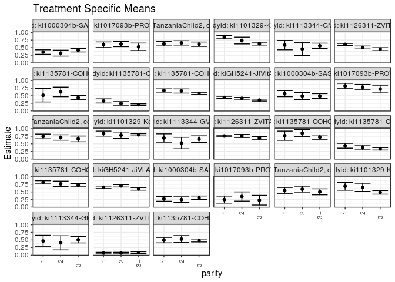

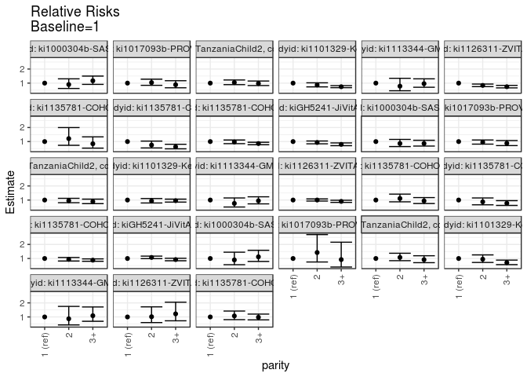

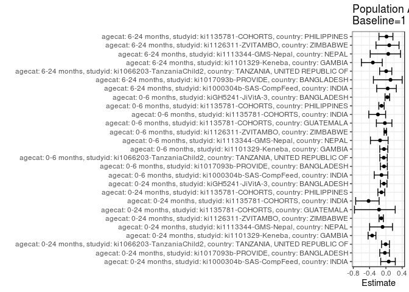

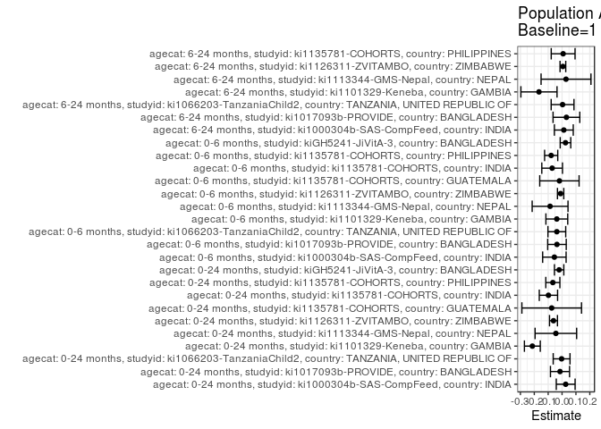

## Results Table

### Parameter: TSM

| agecat | studyid | country | intervention_level | baseline_level | estimate | ci_lower | ci_upper |
| --- | --- | --- | --- | --- | --- | --- | --- |
| 0-24 months | ki1000304b-SAS-CompFeed | INDIA | 1 | NA | 0.3546007 | 0.2803791 | 0.4288223 |
| 0-24 months | ki1000304b-SAS-CompFeed | INDIA | 2 | NA | 0.3186830 | 0.2201564 | 0.4172097 |
| 0-24 months | ki1000304b-SAS-CompFeed | INDIA | 3+ | NA | 0.4141764 | 0.3571204 | 0.4712324 |
| 0-24 months | ki1017093b-PROVIDE | BANGLADESH | 1 | NA | 0.5959068 | 0.5035813 | 0.6882324 |
| 0-24 months | ki1017093b-PROVIDE | BANGLADESH | 2 | NA | 0.6188228 | 0.5324236 | 0.7052219 |
| 0-24 months | ki1017093b-PROVIDE | BANGLADESH | 3+ | NA | 0.5273922 | 0.4048506 | 0.6499337 |
| 0-24 months | ki1066203-TanzaniaChild2 | TANZANIA, UNITED REPUBLIC OF | 1 | NA | 0.6285964 | 0.5575109 | 0.6996819 |
| 0-24 months | ki1066203-TanzaniaChild2 | TANZANIA, UNITED REPUBLIC OF | 2 | NA | 0.6562518 | 0.5842029 | 0.7283007 |
| 0-24 months | ki1066203-TanzaniaChild2 | TANZANIA, UNITED REPUBLIC OF | 3+ | NA | 0.6126518 | 0.5404834 | 0.6848202 |
| 0-24 months | ki1101329-Keneba | GAMBIA | 1 | NA | 0.8482272 | 0.7934104 | 0.9030440 |
| 0-24 months | ki1101329-Keneba | GAMBIA | 2 | NA | 0.7343786 | 0.6221591 | 0.8465982 |
| 0-24 months | ki1101329-Keneba | GAMBIA | 3+ | NA | 0.6310861 | 0.5847201 | 0.6774522 |
| 0-24 months | ki1113344-GMS-Nepal | NEPAL | 1 | NA | 0.5842175 | 0.4293487 | 0.7390863 |
| 0-24 months | ki1113344-GMS-Nepal | NEPAL | 2 | NA | 0.4572806 | 0.2422285 | 0.6723326 |
| 0-24 months | ki1113344-GMS-Nepal | NEPAL | 3+ | NA | 0.5607237 | 0.4739326 | 0.6475149 |
| 0-24 months | ki1126311-ZVITAMBO | ZIMBABWE | 1 | NA | 0.6049790 | 0.5724588 | 0.6374992 |
| 0-24 months | ki1126311-ZVITAMBO | ZIMBABWE | 2 | NA | 0.5054892 | 0.4575741 | 0.5534042 |
| 0-24 months | ki1126311-ZVITAMBO | ZIMBABWE | 3+ | NA | 0.4507226 | 0.4026384 | 0.4988067 |
| 0-24 months | ki1135781-COHORTS | GUATEMALA | 1 | NA | 0.5166880 | 0.2943018 | 0.7390743 |
| 0-24 months | ki1135781-COHORTS | GUATEMALA | 2 | NA | 0.6257302 | 0.4670771 | 0.7843833 |
| 0-24 months | ki1135781-COHORTS | GUATEMALA | 3+ | NA | 0.4363816 | 0.3677345 | 0.5050287 |
| 0-24 months | ki1135781-COHORTS | INDIA | 1 | NA | 0.3287317 | 0.2587178 | 0.3987456 |
| 0-24 months | ki1135781-COHORTS | INDIA | 2 | NA | 0.2474116 | 0.1889996 | 0.3058235 |
| 0-24 months | ki1135781-COHORTS | INDIA | 3+ | NA | 0.2057572 | 0.1772511 | 0.2342633 |
| 0-24 months | ki1135781-COHORTS | PHILIPPINES | 1 | NA | 0.6731504 | 0.6190392 | 0.7272616 |
| 0-24 months | ki1135781-COHORTS | PHILIPPINES | 2 | NA | 0.6550839 | 0.5858199 | 0.7243480 |
| 0-24 months | ki1135781-COHORTS | PHILIPPINES | 3+ | NA | 0.5779429 | 0.5417917 | 0.6140941 |
| 0-24 months | kiGH5241-JiVitA-3 | BANGLADESH | 1 | NA | 0.4431226 | 0.4075948 | 0.4786505 |
| 0-24 months | kiGH5241-JiVitA-3 | BANGLADESH | 2 | NA | 0.4147882 | 0.3846139 | 0.4449626 |
| 0-24 months | kiGH5241-JiVitA-3 | BANGLADESH | 3+ | NA | 0.3549280 | 0.3225907 | 0.3872652 |

[output cut: 51 more lines]

### Parameter: E(Y)

| agecat | studyid | country | intervention_level | baseline_level | estimate | ci_lower | ci_upper |
| --- | --- | --- | --- | --- | --- | --- | --- |
| 0-24 months | ki1000304b-SAS-CompFeed | INDIA | NA | NA | 0.3808354 | 0.3457640 | 0.4159068 |
| 0-24 months | ki1017093b-PROVIDE | BANGLADESH | NA | NA | 0.5811688 | 0.5245443 | 0.6377934 |
| 0-24 months | ki1066203-TanzaniaChild2 | TANZANIA, UNITED REPUBLIC OF | NA | NA | 0.6253561 | 0.5873792 | 0.6633330 |
| 0-24 months | ki1101329-Keneba | GAMBIA | NA | NA | 0.6342142 | 0.6073589 | 0.6610695 |
| 0-24 months | ki1113344-GMS-Nepal | NEPAL | NA | NA | 0.5396579 | 0.4973524 | 0.5819633 |
| 0-24 months | ki1126311-ZVITAMBO | ZIMBABWE | NA | NA | 0.5432918 | 0.5268968 | 0.5596869 |
| 0-24 months | ki1135781-COHORTS | GUATEMALA | NA | NA | 0.4421053 | 0.3904403 | 0.4937702 |
| 0-24 months | ki1135781-COHORTS | INDIA | NA | NA | 0.2306792 | 0.2105836 | 0.2507747 |
| 0-24 months | ki1135781-COHORTS | PHILIPPINES | NA | NA | 0.6068680 | 0.5823645 | 0.6313715 |
| 0-24 months | kiGH5241-JiVitA-3 | BANGLADESH | NA | NA | 0.4221371 | 0.4110175 | 0.4332567 |
| 0-6 months | ki1000304b-SAS-CompFeed | INDIA | NA | NA | 0.5131965 | 0.4596632 | 0.5667297 |
| 0-6 months | ki1017093b-PROVIDE | BANGLADESH | NA | NA | 0.7837838 | 0.7252863 | 0.8422812 |
| 0-6 months | ki1066203-TanzaniaChild2 | TANZANIA, UNITED REPUBLIC OF | NA | NA | 0.7053571 | 0.6558827 | 0.7548316 |
| 0-6 months | ki1101329-Keneba | GAMBIA | NA | NA | 0.7989865 | 0.7673199 | 0.8306531 |
| 0-6 months | ki1113344-GMS-Nepal | NEPAL | NA | NA | 0.6045627 | 0.5449300 | 0.6641955 |
| 0-6 months | ki1126311-ZVITAMBO | ZIMBABWE | NA | NA | 0.7475189 | 0.7305656 | 0.7644721 |
| 0-6 months | ki1135781-COHORTS | GUATEMALA | NA | NA | 0.7476636 | 0.6894668 | 0.8058603 |
| 0-6 months | ki1135781-COHORTS | INDIA | NA | NA | 0.3641405 | 0.3354558 | 0.3928252 |
| 0-6 months | ki1135781-COHORTS | PHILIPPINES | NA | NA | 0.7367021 | 0.7051294 | 0.7682749 |
| 0-6 months | kiGH5241-JiVitA-3 | BANGLADESH | NA | NA | 0.6751162 | 0.6617750 | 0.6884574 |
| 6-24 months | ki1000304b-SAS-CompFeed | INDIA | NA | NA | 0.2854123 | 0.2436284 | 0.3271961 |
| 6-24 months | ki1017093b-PROVIDE | BANGLADESH | NA | NA | 0.2764228 | 0.1950773 | 0.3577682 |
| 6-24 months | ki1066203-TanzaniaChild2 | TANZANIA, UNITED REPUBLIC OF | NA | NA | 0.5519126 | 0.4992021 | 0.6046230 |
| 6-24 months | ki1101329-Keneba | GAMBIA | NA | NA | 0.5189125 | 0.4826376 | 0.5551875 |
| 6-24 months | ki1113344-GMS-Nepal | NEPAL | NA | NA | 0.4947368 | 0.4401559 | 0.5493178 |
| 6-24 months | ki1126311-ZVITAMBO | ZIMBABWE | NA | NA | 0.0739051 | 0.0584895 | 0.0893208 |
| 6-24 months | ki1135781-COHORTS | PHILIPPINES | NA | NA | 0.5026681 | 0.4688378 | 0.5364984 |

### Parameter: RR

| agecat | studyid | country | intervention_level | baseline_level | estimate | ci_lower | ci_upper |
| --- | --- | --- | --- | --- | --- | --- | --- |
| 0-24 months | ki1000304b-SAS-CompFeed | INDIA | 1 | 1 | 1.0000000 | 1.0000000 | 1.0000000 |
| 0-24 months | ki1000304b-SAS-CompFeed | INDIA | 2 | 1 | 0.8987096 | 0.6187633 | 1.3053115 |
| 0-24 months | ki1000304b-SAS-CompFeed | INDIA | 3+ | 1 | 1.1680078 | 0.9095612 | 1.4998905 |
| 0-24 months | ki1017093b-PROVIDE | BANGLADESH | 1 | 1 | 1.0000000 | 1.0000000 | 1.0000000 |
| 0-24 months | ki1017093b-PROVIDE | BANGLADESH | 2 | 1 | 1.0384556 | 0.8421760 | 1.2804805 |
| 0-24 months | ki1017093b-PROVIDE | BANGLADESH | 3+ | 1 | 0.8850245 | 0.6691917 | 1.1704695 |
| 0-24 months | ki1066203-TanzaniaChild2 | TANZANIA, UNITED REPUBLIC OF | 1 | 1 | 1.0000000 | 1.0000000 | 1.0000000 |
| 0-24 months | ki1066203-TanzaniaChild2 | TANZANIA, UNITED REPUBLIC OF | 2 | 1 | 1.0439955 | 0.8916404 | 1.2223835 |
| 0-24 months | ki1066203-TanzaniaChild2 | TANZANIA, UNITED REPUBLIC OF | 3+ | 1 | 0.9746346 | 0.8277551 | 1.1475769 |
| 0-24 months | ki1101329-Keneba | GAMBIA | 1 | 1 | 1.0000000 | 1.0000000 | 1.0000000 |
| 0-24 months | ki1101329-Keneba | GAMBIA | 2 | 1 | 0.8657806 | 0.7333462 | 1.0221311 |
| 0-24 months | ki1101329-Keneba | GAMBIA | 3+ | 1 | 0.7440060 | 0.6745417 | 0.8206237 |
| 0-24 months | ki1113344-GMS-Nepal | NEPAL | 1 | 1 | 1.0000000 | 1.0000000 | 1.0000000 |
| 0-24 months | ki1113344-GMS-Nepal | NEPAL | 2 | 1 | 0.7827232 | 0.4563392 | 1.3425441 |
| 0-24 months | ki1113344-GMS-Nepal | NEPAL | 3+ | 1 | 0.9597859 | 0.7061026 | 1.3046108 |
| 0-24 months | ki1126311-ZVITAMBO | ZIMBABWE | 1 | 1 | 1.0000000 | 1.0000000 | 1.0000000 |
| 0-24 months | ki1126311-ZVITAMBO | ZIMBABWE | 2 | 1 | 0.8355483 | 0.7495781 | 0.9313785 |
| 0-24 months | ki1126311-ZVITAMBO | ZIMBABWE | 3+ | 1 | 0.7450219 | 0.6615612 | 0.8390118 |
| 0-24 months | ki1135781-COHORTS | GUATEMALA | 1 | 1 | 1.0000000 | 1.0000000 | 1.0000000 |
| 0-24 months | ki1135781-COHORTS | GUATEMALA | 2 | 1 | 1.2110406 | 0.7350766 | 1.9951924 |
| 0-24 months | ki1135781-COHORTS | GUATEMALA | 3+ | 1 | 0.8445746 | 0.5336421 | 1.3366752 |
| 0-24 months | ki1135781-COHORTS | INDIA | 1 | 1 | 1.0000000 | 1.0000000 | 1.0000000 |
| 0-24 months | ki1135781-COHORTS | INDIA | 2 | 1 | 0.7526247 | 0.5475994 | 1.0344131 |
| 0-24 months | ki1135781-COHORTS | INDIA | 3+ | 1 | 0.6259123 | 0.4855022 | 0.8069299 |
| 0-24 months | ki1135781-COHORTS | PHILIPPINES | 1 | 1 | 1.0000000 | 1.0000000 | 1.0000000 |
| 0-24 months | ki1135781-COHORTS | PHILIPPINES | 2 | 1 | 0.9731612 | 0.8522784 | 1.1111895 |
| 0-24 months | ki1135781-COHORTS | PHILIPPINES | 3+ | 1 | 0.8585642 | 0.7754541 | 0.9505818 |
| 0-24 months | kiGH5241-JiVitA-3 | BANGLADESH | 1 | 1 | 1.0000000 | 1.0000000 | 1.0000000 |
| 0-24 months | kiGH5241-JiVitA-3 | BANGLADESH | 2 | 1 | 0.9360574 | 0.8400278 | 1.0430649 |
| 0-24 months | kiGH5241-JiVitA-3 | BANGLADESH | 3+ | 1 | 0.8009700 | 0.7094358 | 0.9043144 |

[output cut: 51 more lines]

### Parameter: PAR

| agecat | studyid | country | intervention_level | baseline_level | estimate | ci_lower | ci_upper |
| --- | --- | --- | --- | --- | --- | --- | --- |
| 0-24 months | ki1000304b-SAS-CompFeed | INDIA | 1 | NA | 0.0262347 | -0.0415284 | 0.0939978 |
| 0-24 months | ki1017093b-PROVIDE | BANGLADESH | 1 | NA | -0.0147380 | -0.0835288 | 0.0540528 |
| 0-24 months | ki1066203-TanzaniaChild2 | TANZANIA, UNITED REPUBLIC OF | 1 | NA | -0.0032403 | -0.0637915 | 0.0573109 |
| 0-24 months | ki1101329-Keneba | GAMBIA | 1 | NA | -0.2140130 | -0.2711483 | -0.1568777 |
| 0-24 months | ki1113344-GMS-Nepal | NEPAL | 1 | NA | -0.0445596 | -0.1942792 | 0.1051599 |
| 0-24 months | ki1126311-ZVITAMBO | ZIMBABWE | 1 | NA | -0.0616871 | -0.0903132 | -0.0330610 |
| 0-24 months | ki1135781-COHORTS | GUATEMALA | 1 | NA | -0.0745828 | -0.2893623 | 0.1401968 |
| 0-24 months | ki1135781-COHORTS | INDIA | 1 | NA | -0.0980525 | -0.1639495 | -0.0321555 |
| 0-24 months | ki1135781-COHORTS | PHILIPPINES | 1 | NA | -0.0662825 | -0.1169585 | -0.0156064 |
| 0-24 months | kiGH5241-JiVitA-3 | BANGLADESH | 1 | NA | -0.0209855 | -0.0547080 | 0.0127369 |
| 0-6 months | ki1000304b-SAS-CompFeed | INDIA | 1 | NA | -0.0552583 | -0.1397355 | 0.0292189 |
| 0-6 months | ki1017093b-PROVIDE | BANGLADESH | 1 | NA | -0.0366196 | -0.1034011 | 0.0301618 |
| 0-6 months | ki1066203-TanzaniaChild2 | TANZANIA, UNITED REPUBLIC OF | 1 | NA | -0.0375823 | -0.1016326 | 0.0264679 |
| 0-6 months | ki1101329-Keneba | GAMBIA | 1 | NA | -0.0376797 | -0.1163222 | 0.0409628 |
| 0-6 months | ki1113344-GMS-Nepal | NEPAL | 1 | NA | -0.0862111 | -0.2153048 | 0.0428826 |
| 0-6 months | ki1126311-ZVITAMBO | ZIMBABWE | 1 | NA | -0.0102815 | -0.0330654 | 0.0125024 |
| 0-6 months | ki1135781-COHORTS | GUATEMALA | 1 | NA | -0.0190031 | -0.1607938 | 0.1227875 |
| 0-6 months | ki1135781-COHORTS | INDIA | 1 | NA | -0.0713812 | -0.1458682 | 0.0031058 |
| 0-6 months | ki1135781-COHORTS | PHILIPPINES | 1 | NA | -0.0783576 | -0.1257519 | -0.0309632 |
| 0-6 months | kiGH5241-JiVitA-3 | BANGLADESH | 1 | NA | 0.0247935 | -0.0132413 | 0.0628283 |
| 6-24 months | ki1000304b-SAS-CompFeed | INDIA | 1 | NA | 0.0127078 | -0.0553042 | 0.0807198 |
| 6-24 months | ki1017093b-PROVIDE | BANGLADESH | 1 | NA | 0.0315248 | -0.0648316 | 0.1278812 |
| 6-24 months | ki1066203-TanzaniaChild2 | TANZANIA, UNITED REPUBLIC OF | 1 | NA | 0.0037671 | -0.0783783 | 0.0859125 |
| 6-24 months | ki1101329-Keneba | GAMBIA | 1 | NA | -0.1662713 | -0.2963568 | -0.0361858 |
| 6-24 months | ki1113344-GMS-Nepal | NEPAL | 1 | NA | 0.0286044 | -0.1510899 | 0.2082987 |
| 6-24 months | ki1126311-ZVITAMBO | ZIMBABWE | 1 | NA | 0.0060849 | -0.0145000 | 0.0266699 |
| 6-24 months | ki1135781-COHORTS | PHILIPPINES | 1 | NA | 0.0078181 | -0.0779623 | 0.0935985 |

### Parameter: PAF

| agecat | studyid | country | intervention_level | baseline_level | estimate | ci_lower | ci_upper |
| --- | --- | --- | --- | --- | --- | --- | --- |
| 0-24 months | ki1000304b-SAS-CompFeed | INDIA | 1 | NA | 0.0688872 | -0.1268145 | 0.2306000 |
| 0-24 months | ki1017093b-PROVIDE | BANGLADESH | 1 | NA | -0.0253593 | -0.1506487 | 0.0862879 |
| 0-24 months | ki1066203-TanzaniaChild2 | TANZANIA, UNITED REPUBLIC OF | 1 | NA | -0.0051815 | -0.1068299 | 0.0871319 |
| 0-24 months | ki1101329-Keneba | GAMBIA | 1 | NA | -0.3374460 | -0.4365654 | -0.2451656 |
| 0-24 months | ki1113344-GMS-Nepal | NEPAL | 1 | NA | -0.0825702 | -0.3990394 | 0.1623122 |
| 0-24 months | ki1126311-ZVITAMBO | ZIMBABWE | 1 | NA | -0.1135433 | -0.1677337 | -0.0618677 |
| 0-24 months | ki1135781-COHORTS | GUATEMALA | 1 | NA | -0.1686991 | -0.7707798 | 0.2286688 |
| 0-24 months | ki1135781-COHORTS | INDIA | 1 | NA | -0.4250602 | -0.7416427 | -0.1660237 |
| 0-24 months | ki1135781-COHORTS | PHILIPPINES | 1 | NA | -0.1092206 | -0.1965326 | -0.0282798 |
| 0-24 months | kiGH5241-JiVitA-3 | BANGLADESH | 1 | NA | -0.0497126 | -0.1327249 | 0.0272160 |
| 0-6 months | ki1000304b-SAS-CompFeed | INDIA | 1 | NA | -0.1076748 | -0.2856276 | 0.0456463 |
| 0-6 months | ki1017093b-PROVIDE | BANGLADESH | 1 | NA | -0.0467216 | -0.1356711 | 0.0352612 |
| 0-6 months | ki1066203-TanzaniaChild2 | TANZANIA, UNITED REPUBLIC OF | 1 | NA | -0.0532813 | -0.1484848 | 0.0340303 |
| 0-6 months | ki1101329-Keneba | GAMBIA | 1 | NA | -0.0471594 | -0.1505018 | 0.0469005 |
| 0-6 months | ki1113344-GMS-Nepal | NEPAL | 1 | NA | -0.1426007 | -0.3793492 | 0.0535128 |
| 0-6 months | ki1126311-ZVITAMBO | ZIMBABWE | 1 | NA | -0.0137541 | -0.0447078 | 0.0162824 |
| 0-6 months | ki1135781-COHORTS | GUATEMALA | 1 | NA | -0.0254167 | -0.2337815 | 0.1477589 |
| 0-6 months | ki1135781-COHORTS | INDIA | 1 | NA | -0.1960265 | -0.4201535 | -0.0072709 |
| 0-6 months | ki1135781-COHORTS | PHILIPPINES | 1 | NA | -0.1063626 | -0.1736140 | -0.0429650 |
| 0-6 months | kiGH5241-JiVitA-3 | BANGLADESH | 1 | NA | 0.0367248 | -0.0212987 | 0.0914518 |
| 6-24 months | ki1000304b-SAS-CompFeed | INDIA | 1 | NA | 0.0445242 | -0.2260144 | 0.2553644 |
| 6-24 months | ki1017093b-PROVIDE | BANGLADESH | 1 | NA | 0.1140456 | -0.3070302 | 0.3994667 |
| 6-24 months | ki1066203-TanzaniaChild2 | TANZANIA, UNITED REPUBLIC OF | 1 | NA | 0.0068254 | -0.1537468 | 0.1450501 |
| 6-24 months | ki1101329-Keneba | GAMBIA | 1 | NA | -0.3204226 | -0.6009061 | -0.0890807 |
| 6-24 months | ki1113344-GMS-Nepal | NEPAL | 1 | NA | 0.0578174 | -0.3853667 | 0.3592252 |
| 6-24 months | ki1126311-ZVITAMBO | ZIMBABWE | 1 | NA | 0.0823344 | -0.2430110 | 0.3225239 |
| 6-24 months | ki1135781-COHORTS | PHILIPPINES | 1 | NA | 0.0155532 | -0.1706780 | 0.1721588 |